# WRITE UP of ENCODE-DREAM in vivo Transcription Factor Binding Site Prediction Challenge

Name: maximus  
Ricardo Paixao dos Santos  
Prof. Katlin Brauer Massirer, Ph.D.  
Lab of RNA and microRNA Regulation in Disease,  
Center for Molecular Biology and Genetic Engineering  
University of Campinas, UNICAMP  
Av Candido Rondon, 400 Campinas,13083-875, Brazil

## Introduction

The model consist of a ensemble of 100 RandomForest (Breiman, 2001) (that already is a ensemble of Decision Trees), combined with xgboost (Chen et al., 2015) predictions. The choice of this approach had the aim to avoid overfitting. Random Forests have the property of reducing variance keeping the bias low (Breiman, 2001), which gives to this algorithm a good power of generalization, fundamental on unseen data as in this competition, and relativelly easier to tune its parameters. Gradient Boosting Machine has competitive perfomace, outperforming RandomForests in some problems. Since their arquitetures are differents, their combination can improve the predictive performance, a fact observed in (Marbach et al., 2012).

## Methods

### Parameters

- Each one of the 100 RandomForests models were set on the same parameters and their predictions were combined with simple mean. Tunning was made using 3-fold cross validation on some trainning sets. The GBM was used with the R package XGBoost and the parameters set using the xgb.cv (cross validation) For each trainning and test set,we used the information from ChIP-Seq, DNASE fold coverage, DNASE peaks conservative fold, annotations from Ensembl and the average and maximum values motifs scores. It was not possible to use the DNAshape data because of the amount of RAM memory needed and time necessary to process this task.

### PreProcessing

- The motifs scores were calculated with the meme suite (software ame (McLeay and Bailey, 2010)). These scores and the parameter maxfc (max fold change dnase) were log10 transformed. These parameters, and others from DNASE experiments were obtained with both the average and maximum values. Once the randomForest has scale problems, all numeric variables was scaled to mean zero and standard deviation 1.

#### Prediction Error(MSE) vs Rsquared of 100 RandomForest to Predict ‘ATF2’ Binding Sites

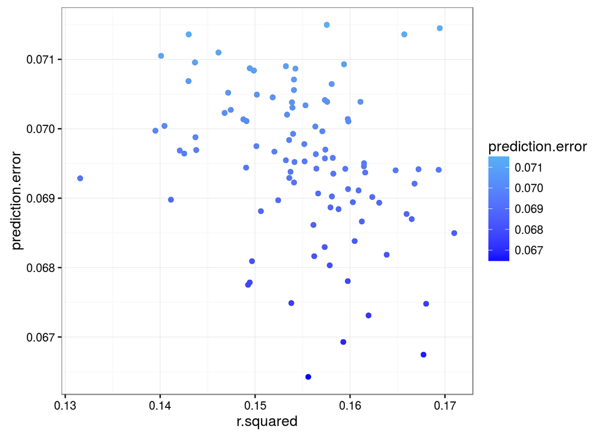

## References

Breiman, L. (2001). Random Forests. European Journal of Mathematics *45*, 5–32.

Chen, T., He, T., Benesty, M., Khotilovich, V., and Tang, Y. (2015). Xgboost: Extreme gradient boosting.

Marbach, D., Costello, J.C., Küffner, R., Vega, N.M., Prill, R.J., Camacho, D.M., Allison, K.R., Kellis, M., Collins, J.J., and Stolovitzky, G. (2012). Wisdom of crowds for robust gene network inference. Nature Methods *9*, 796–804.

McLeay, R.C., and Bailey, T.L. (2010). Motif Enrichment Analysis: a unified framework and an evaluation on ChIP data. BMC Bioinformatics *11*, 165.